# Business Understanding

- The goal of this project is to understand what affects salaries in data-science jobs and to see if we can predict a job’s salary in USD. We look at factors like where the company is located, the type of job, experience level, employment type, work setting, and company size.
- Our main question is, that we want to answer, is: “Can we predict a data-science salary using job's/ company's features in the provided dataset?”
- This is useful because it helps job seekers know what they can expect to earn, and it helps companies make fair and competitive salary decisions.

### Data Preview

- Here, we will give a preview of what the original csv data looks like before we apply feature engineering to it.

```python
# Preview
import numpy as np
import pandas as pd
import seaborn as sns
import matplotlib.pyplot as plt
from matplotlib.pyplot import figure
from dotenv import load_dotenv
import os

load_dotenv()

csv_path = os.getenv("CSV_PATHNAME") # To avoid conflicts with different pathnames

# Load data
data = pd.read_csv(csv_path)

data
```

[output not shown]

[output cut: 8 more lines]

[output not shown]

```python
# Describe all fields in the data
data.info()
data.head()
print(data.describe())
```

```
<class 'pandas.core.frame.DataFrame'>
RangeIndex: 9355 entries, 0 to 9354
Data columns (total 12 columns):
 #   Column              Non-Null Count  Dtype
---  ------              --------------  -----
 0   work_year           9355 non-null   int64
 1   job_title           9355 non-null   object
 2   job_category        9355 non-null   object
 3   salary_currency     9355 non-null   object
 4   salary              9355 non-null   int64
 5   salary_in_usd       9355 non-null   int64
 6   employee_residence  9355 non-null   object
 7   experience_level    9355 non-null   object
 8   employment_type     9355 non-null   object
 9   work_setting        9355 non-null   object
 10  company_location    9355 non-null   object
 11  company_size        9355 non-null   object
dtypes: int64(3), object(9)
memory usage: 877.2+ KB
         work_year         salary  salary_in_usd
count  9355.000000    9355.000000    9355.000000
mean   2022.760449  149927.981293  150299.495564
std       0.519470   63608.835387   63177.372024
min    2020.000000   14000.000000   15000.000000
25%    2023.000000  105200.000000  105700.000000
50%    2023.000000  143860.000000  143000.000000
75%    2023.000000  187000.000000  186723.000000
max    2023.000000  450000.000000  450000.000000
```

# Data Cleaning

### Handling Missing Data

```python
# Print all fields and sum of any missing values in their respective column
print("Missing Values:")
data.isnull().sum()
```

```
Missing Values:
```

```
work_year             0
job_title             0
job_category          0
salary_currency       0
salary                0
salary_in_usd         0
employee_residence    0
experience_level      0
employment_type       0
work_setting          0
company_location      0
company_size          0
dtype: int64
```

#### Conclusion

- In the untouched dataset, there are absolutely no missing values at all. So there is no need to create any code for accounting for missing values in the dataset

# Data Exploration

- This step will now go through the univariate, bivariate, and multivariate analysis of our cleaned dataset

### Univariate Analysis

```python
# Describe data again to remind ourselves
data.info()
data.describe(include='all')
```

```
<class 'pandas.core.frame.DataFrame'>
RangeIndex: 9355 entries, 0 to 9354
Data columns (total 12 columns):
 #   Column              Non-Null Count  Dtype
---  ------              --------------  -----
 0   work_year           9355 non-null   int64
 1   job_title           9355 non-null   object
 2   job_category        9355 non-null   object
 3   salary_currency     9355 non-null   object
 4   salary              9355 non-null   int64
 5   salary_in_usd       9355 non-null   int64
 6   employee_residence  9355 non-null   object
 7   experience_level    9355 non-null   object
 8   employment_type     9355 non-null   object
 9   work_setting        9355 non-null   object
 10  company_location    9355 non-null   object
 11  company_size        9355 non-null   object
dtypes: int64(3), object(9)
memory usage: 877.2+ KB
```

|  | work_year | job_title | job_category | salary_currency | salary | salary_in_usd | employee_residence | experience_level | employment_type | work_setting | company_location | company_size |
| --- | --- | --- | --- | --- | --- | --- | --- | --- | --- | --- | --- | --- |
| count | 9355.000000 | 9355 | 9355 | 9355 | 9355.000000 | 9355.000000 | 9355 | 9355 | 9355 | 9355 | 9355 | 9355 |
| unique | NaN | 125 | 10 | 11 | NaN | NaN | 83 | 4 | 4 | 3 | 70 | 3 |
| top | NaN | Data Engineer | Data Science and Research | USD | NaN | NaN | United States | Senior | Full-time | In-person | United States | M |
| freq | NaN | 2195 | 3014 | 8591 | NaN | NaN | 8086 | 6709 | 9310 | 5730 | 8132 | 8448 |
| mean | 2022.760449 | NaN | NaN | NaN | 149927.981293 | 150299.495564 | NaN | NaN | NaN | NaN | NaN | NaN |
| std | 0.519470 | NaN | NaN | NaN | 63608.835387 | 63177.372024 | NaN | NaN | NaN | NaN | NaN | NaN |
| min | 2020.000000 | NaN | NaN | NaN | 14000.000000 | 15000.000000 | NaN | NaN | NaN | NaN | NaN | NaN |
| 25% | 2023.000000 | NaN | NaN | NaN | 105200.000000 | 105700.000000 | NaN | NaN | NaN | NaN | NaN | NaN |
| 50% | 2023.000000 | NaN | NaN | NaN | 143860.000000 | 143000.000000 | NaN | NaN | NaN | NaN | NaN | NaN |
| 75% | 2023.000000 | NaN | NaN | NaN | 187000.000000 | 186723.000000 | NaN | NaN | NaN | NaN | NaN | NaN |
| max | 2023.000000 | NaN | NaN | NaN | 450000.000000 | 450000.000000 | NaN | NaN | NaN | NaN | NaN | NaN |

There are 3 numeric columns to perform univariate analysis on. They are:

1. work_year
2. salary
3. salary_in_usd

The rest of the columns are all categorical values. They are:

1. job_title
2. job_category
3. salary_currency
4. employee_residence
5. experience_level
6. employment_type
7. work_setting
8. company_location
9. company_size

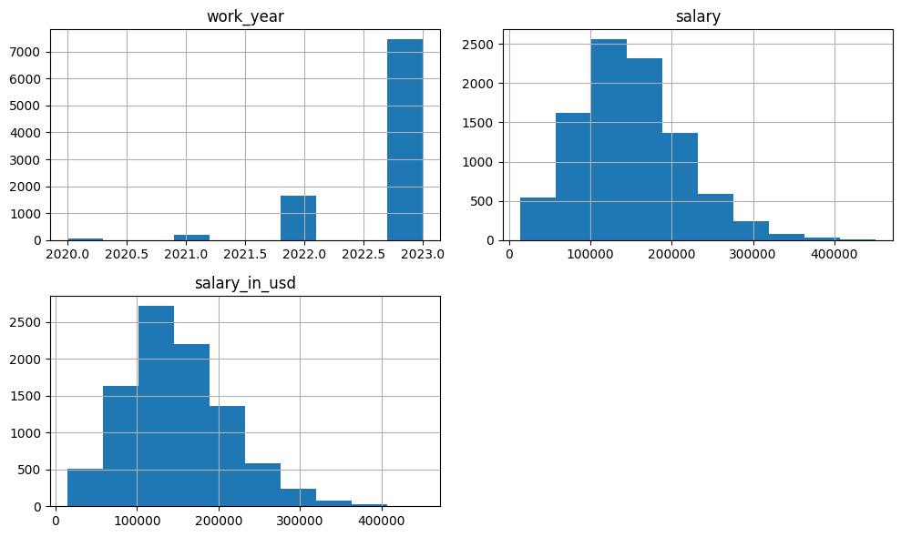

```python
# Histogram of numeric columns
numeric_cols = ['work_year', 'salary', 'salary_in_usd']

data[numeric_cols].hist(figsize=(10,6))
plt.tight_layout()
plt.show()
```

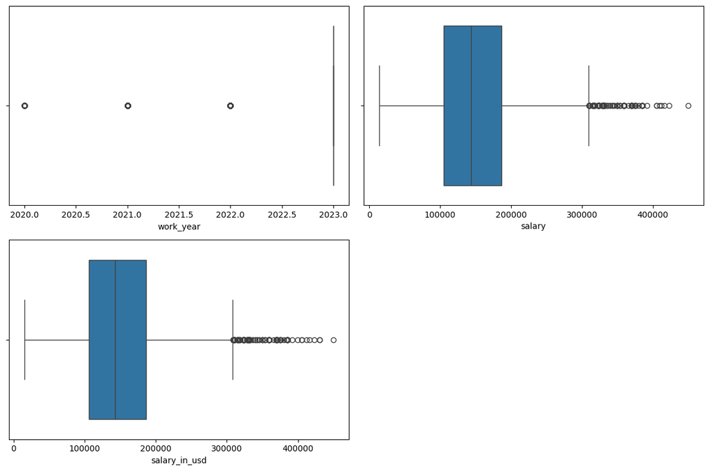

```python
# Boxplots of numeric columns
plt.figure(figsize=(12, 8))

for i, column in enumerate(numeric_cols, 1):
    plt.subplot(2, 2, i)
    sns.boxplot(x=data[column])

plt.tight_layout()
plt.show()
```

```python
# Categorical columns analysis
categorical_cols = ['job_title', 'job_category', 'salary_currency', 'employee_residence',
            'experience_level', 'employment_type', 'work_setting',
            'company_location', 'company_size']

# Print all unique values and their count
for column in categorical_cols:
    print(f"--------------- {column} ---------------")
    print(data[column].value_counts())
    print()
```

```
--------------- job_title ---------------
job_title
Data Engineer                2195
Data Scientist               1989
Data Analyst                 1388
Machine Learning Engineer     991
Applied Scientist             272
                             ...
Deep Learning Researcher        1
Manager Data Management         1
Marketing Data Engineer         1
Data Science Tech Lead          1
Cloud Data Architect            1
Name: count, Length: 125, dtype: int64

--------------- job_category ---------------
job_category
Data Science and Research         3014
Data Engineering                  2260
Data Analysis                     1457
Machine Learning and AI           1428
Leadership and Management          503
BI and Visualization               313
Data Architecture and Modeling     259
Data Management and Strategy        61
Data Quality and Operations         55
Cloud and Database                   5
Name: count, dtype: int64

--------------- salary_currency ---------------
salary_currency
USD    8591
GBP     347
EUR     340
CAD      38
AUD      11
PLN       7
SGD       6
CHF       5
BRL       4
```

[output cut: 48 more lines]

```
Germany             72
                  ...
Iraq                 1
China                1
New Zealand          1
Moldova              1
Malta                1
Name: count, Length: 70, dtype: int64

--------------- company_size ---------------
company_size
M    8448
L     748
S     159
Name: count, dtype: int64
```

```python
# Get fields with few unique values (< 15)
columns_to_plot = []
for column in categorical_cols:
    unique_count = data[column].nunique()
    if unique_count <= 15:
        columns_to_plot.append(column)

print(columns_to_plot)
```

```
['job_category', 'salary_currency', 'experience_level', 'employment_type', 'work_setting', 'company_size']
```

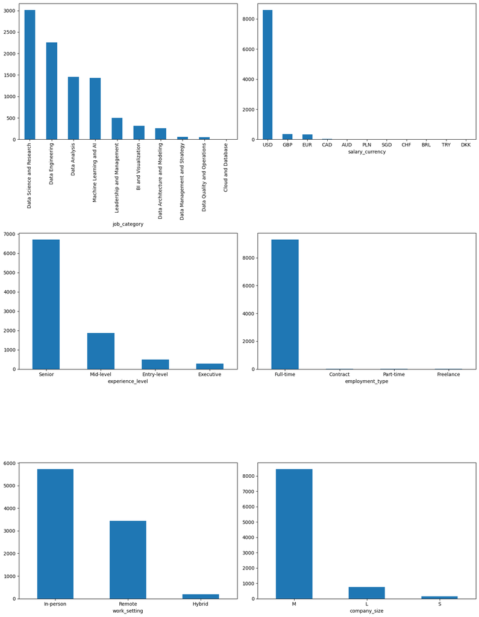

```python
plt.figure(figsize=(14,18))

for i, column in enumerate(columns_to_plot, 1):
    plt.subplot(3, 2, i)
    data[column].value_counts().plot(kind='bar')
    if column == "job_category":
        plt.xticks(rotation=90)
    else:
        plt.xticks(rotation=0)

plt.tight_layout()
plt.show()
```

### Bivariate Analysis

#### Salary vs. Categorical columns

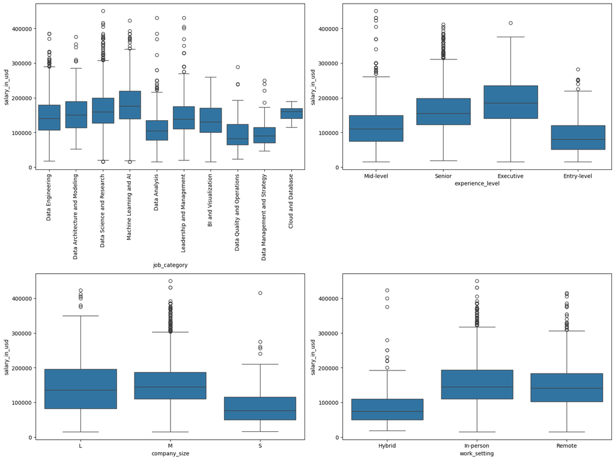

```python
# Compare salary against every categorical category, except job_title and company_location
categorical_cols = ['job_category', 'experience_level', 'company_size', 'work_setting']

plt.figure(figsize=(16, 12))

for i, column in enumerate(categorical_cols, 1):
    plt.subplot(2, 2, i)
    sns.boxplot(x=column, y='salary_in_usd', data=data)

    if column == "job_category":
        plt.xticks(rotation=90)
    else:
        plt.xticks(rotation=0)

plt.tight_layout()
plt.show()
```

#### Salary vs. Numerical columns

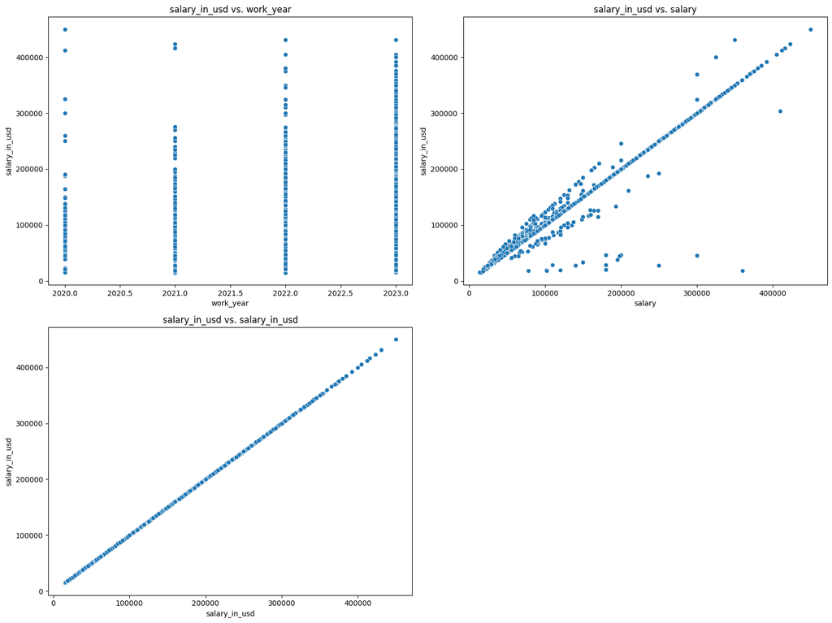

```python
plt.figure(figsize=(16, 12))

for i, column in enumerate(numeric_cols, 1):
    if numeric_cols == "salary_in_usd":
        pass

    plt.subplot(2, 2, i)

    # 1. Use a Scatter Plot for Numeric vs. Numeric
    sns.scatterplot(x=column, y='salary_in_usd', data=data)

    plt.title(f'salary_in_usd vs. {column}')
    plt.xlabel(column)
    plt.ylabel('salary_in_usd')

    # Rotation is less critical for numeric axes but harmless
    plt.xticks(rotation=0)

plt.tight_layout()
plt.show()
```

### Multivariate Analysis

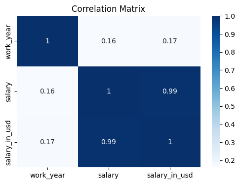

```python
# Multivariate for all numeric columns
numeric_cols = ['work_year', 'salary', 'salary_in_usd']
plt.figure(figsize=(6,4))
sns.heatmap(data[numeric_cols].corr(), annot=True, cmap='Blues')
plt.title("Correlation Matrix")
plt.show()
```

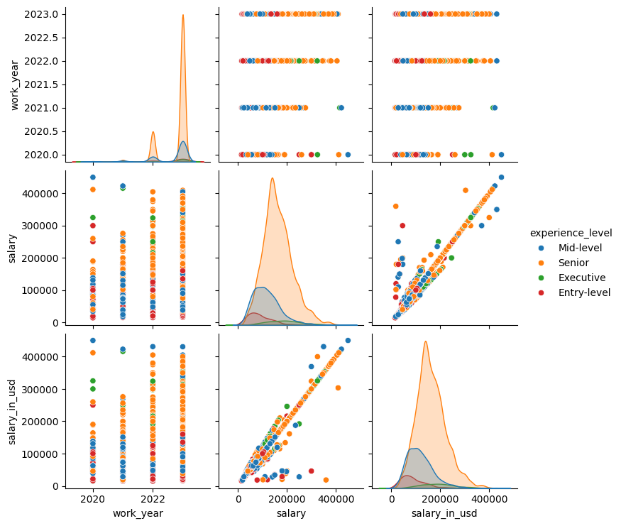

```python
# Visualise pairwise relationships
sns.pairplot(data[numeric_cols + ['experience_level']], hue='experience_level')
plt.show()
```

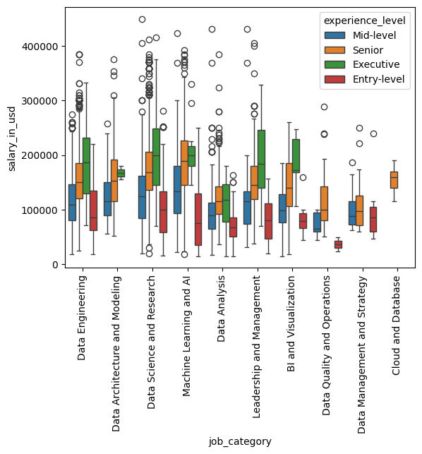

```python
# salary_in_use vs job_category split by experience_level
sns.boxplot(x='job_category', y='salary_in_usd', hue='experience_level', data=data)
plt.xticks(rotation=90)
plt.show()
```

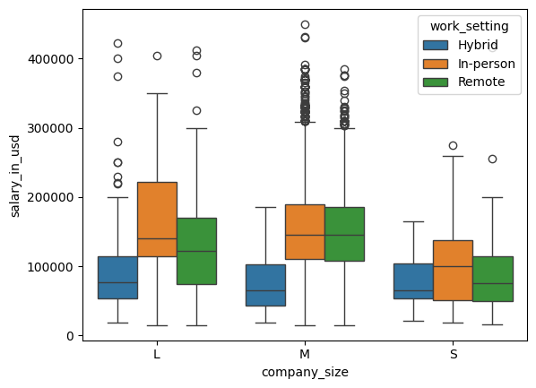

```python
# salary vs company_size split by work_setting
sns.boxplot(x='company_size', y='salary_in_usd', hue='work_setting', data=data)
plt.show()
```

```python
# Average salary_in_usd by company_size and experience_level
data.groupby(['company_size', 'experience_level'])['salary_in_usd'].mean().unstack()
```

| experience_level company_size | Entry-level | Executive | Mid-level | Senior |
| --- | --- | --- | --- | --- |
| L | 78434.952381 | 190198.277778 | 114182.006024 | 163240.143791 |
| M | 93814.210983 | 189697.449219 | 119376.383212 | 162660.737182 |
| S | 71508.044444 | 178994.714286 | 75308.745763 | 114544.416667 |

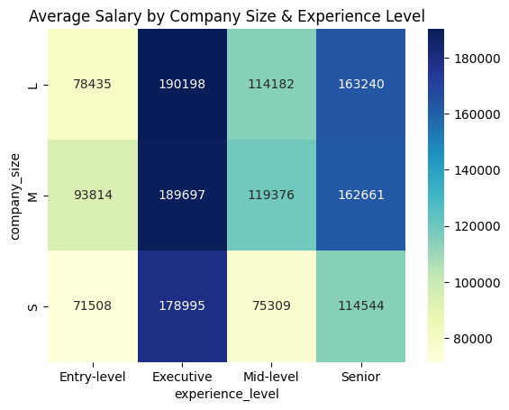

```python
# Plot above as a heatmap
sns.heatmap(
    data.groupby(['company_size', 'experience_level'])['salary_in_usd'].mean().unstack(),
    annot=True, fmt=".0f", cmap="YlGnBu"
)
plt.title("Average Salary by Company Size & Experience Level")
plt.show()
```

# Feature Engineering

### Response variable

- For the dataset we are using, we will be building a prediction model for the salary_in_usd field

### Variable Selection and Creation

```python
# Step 2: Drop variables not useful for modeling
data.drop(['salary_currency', 'job_title', 'salary', 'employee_residence'], axis=1, inplace=True)

# Step 3: Construct New Variables

# make 'company_location' categorical with top 6 locations, rest as 'Other'
top_6 = data['company_location'].value_counts().nlargest(6).index

data['company_location'] = np.where(data['company_location'].isin(top_6),
                                    data['company_location'],
                                    'Other')

# Convert all categorical columns to numeric codes
categorical_cols = ['company_location', 'job_category', 'experience_level',
                    'employment_type', 'work_setting', 'company_size']

for col in categorical_cols:
    data[col + '_code'] = data[col].astype('category').cat.codes

# drop original categorical columns
data_numeric = data.drop(columns=categorical_cols)

# Check result
data_numeric.head()
```

|  | work_year | salary_in_usd | company_location_code | job_category_code | experience_level_code | employment_type_code | work_setting_code | company_size_code |
| --- | --- | --- | --- | --- | --- | --- | --- | --- |
| 0 | 2023 | 95012 | 2 | 4 | 2 | 2 | 0 | 0 |
| 1 | 2023 | 186000 | 6 | 3 | 3 | 2 | 1 | 1 |
| 2 | 2023 | 81800 | 6 | 3 | 3 | 2 | 1 | 1 |
| 3 | 2023 | 212000 | 6 | 7 | 3 | 2 | 1 | 1 |
| 4 | 2023 | 93300 | 6 | 7 | 3 | 2 | 1 | 1 |

### Importance and Multicolinearity

```
                       work_year  salary_in_usd  company_location_code  \
work_year               1.000000       0.166003               0.182609
salary_in_usd           0.166003       1.000000               0.223684
company_location_code   0.182609       0.223684               1.000000
job_category_code       0.010970       0.295061              -0.041604
experience_level_code   0.144390       0.281472               0.141378
employment_type_code    0.043098       0.015168               0.027217
work_setting_code      -0.068513      -0.021230               0.020757
company_size_code       0.112634      -0.014439               0.037594

                       job_category_code  experience_level_code  \
work_year                       0.010970               0.144390
salary_in_usd                   0.295061               0.281472
company_location_code          -0.041604               0.141378
job_category_code               1.000000               0.053191
experience_level_code           0.053191               1.000000
employment_type_code           -0.014530               0.007479
work_setting_code              -0.055707               0.048659
company_size_code               0.022919               0.027679

                       employment_type_code  work_setting_code  \
work_year                          0.043098          -0.068513
salary_in_usd                      0.015168          -0.021230
company_location_code              0.027217           0.020757
job_category_code                 -0.014530          -0.055707
experience_level_code              0.007479           0.048659
employment_type_code               1.000000          -0.036084
work_setting_code                 -0.036084           1.000000
company_size_code                 -0.027345           0.088940

                       company_size_code
work_year                       0.112634
salary_in_usd                  -0.014439
company_location_code           0.037594
job_category_code               0.022919
experience_level_code           0.027679
employment_type_code           -0.027345
work_setting_code               0.088940
company_size_code               1.000000
```

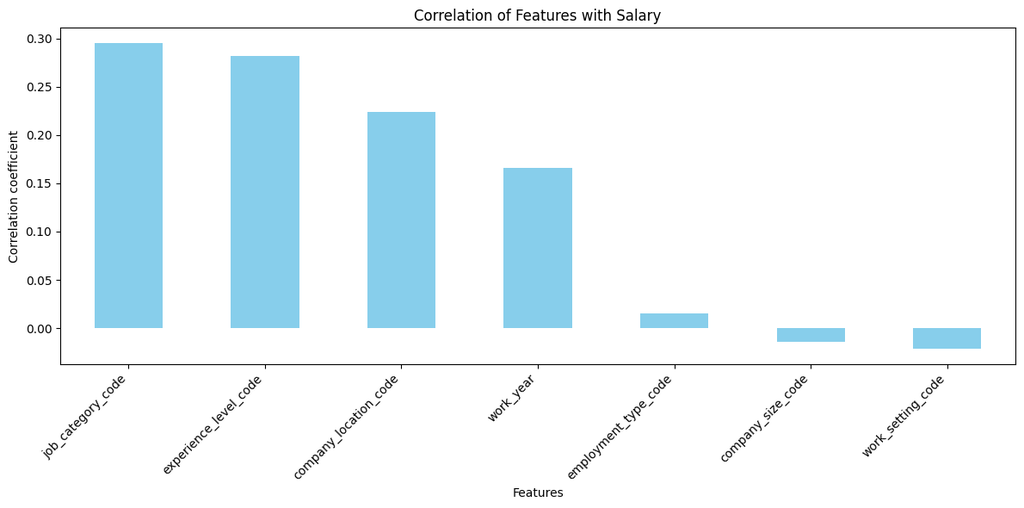

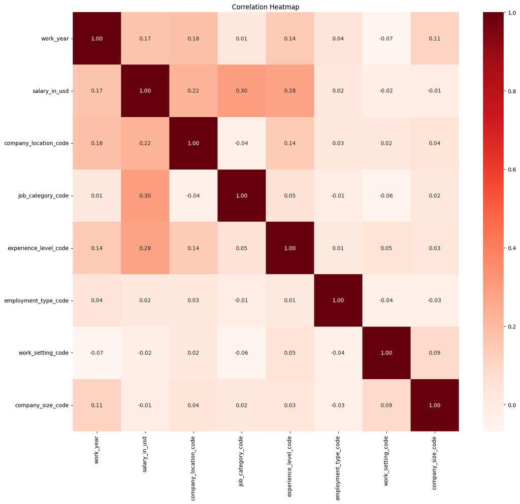

```python
# Step 5: Importance & Multicolinearity

# Correlation matrix for all numeric features
corrVals = data_numeric.corr()
print(corrVals)

# Compute correlation with target (salary_in_usd)
target_corr = data_numeric.corr()['salary_in_usd'].drop('salary_in_usd')  # drop self-correlation

# Sort correlations
target_corr = target_corr.sort_values(ascending=False)

# Plot as bar chart
plt.figure(figsize=(12,6))
target_corr.plot(kind='bar', color='skyblue')
plt.title("Correlation of Features with Salary")
plt.ylabel("Correlation coefficient")
plt.xlabel("Features")
plt.xticks(rotation=45, ha='right')
plt.tight_layout()
plt.show()

#Correlations
plt.figure(figsize=(16, 14))
sns.heatmap(data_numeric.corr(), annot=True, cmap='Reds', fmt=".2f")
plt.title("Correlation Heatmap")
plt.show()
```

# Predictive Modelling

## Regression Modelling

### Step 1: Train-Test Split

```python
from sklearn.tree import DecisionTreeRegressor
from sklearn.model_selection import train_test_split
from sklearn import tree
from sklearn.metrics import mean_absolute_error, mean_squared_error, r2_score
```

```python
# Predictors and response
x = data[['work_year',
          'company_location_code',
          'job_category_code',
          'experience_level_code',
          'employment_type_code',
          'work_setting_code',
          'company_size_code']]
y = data_numeric['salary_in_usd']

# Industry standard, using 20% of data for testing, other 80% for training
x_train, x_test, y_train, y_test = train_test_split(x, y, test_size = 0.2, random_state=111)

# Check size of training and test sets
print("length of Training Set: "+str(len(y_train)))
print("length of Test Set: "+str(len(y_test)))
```

```
length of Training Set: 7484
length of Test Set: 1871
```

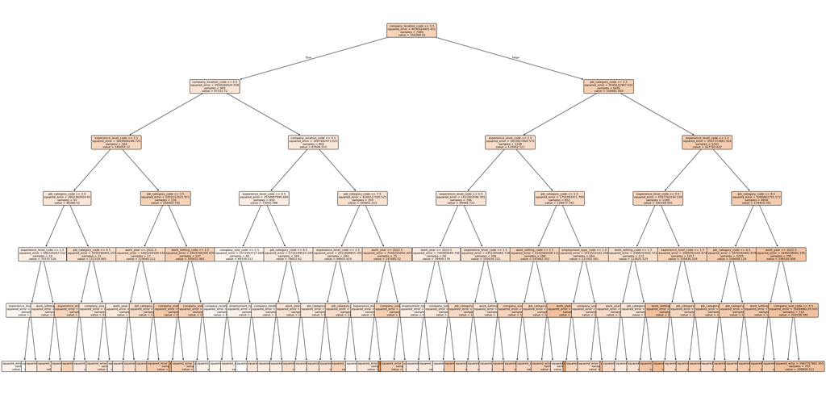

```python
# Using regressor as response is numerical
model = DecisionTreeRegressor(max_depth=6, random_state=42)
model.fit(x_train, y_train)

#Graph the decision tree to understand how it is predicting the outcome
plt.figure(figsize=(40, 20))
tree.plot_tree(
    model,
    feature_names=x.columns,
    filled=True,
    rounded=True,
    fontsize=8
)

plt.show()
```

```python
predictions = model.predict(x_test)

mae = mean_absolute_error(y_test, predictions)
mse = mean_squared_error(y_test, predictions)
rmse = np.sqrt(mse)
r2 = r2_score(y_test, predictions)

print("Mean Absolute Error (MAE):", mae)
print("Root Mean Squared Error (RMSE):", rmse)
print("R^2 Score:", r2)
```

```
Mean Absolute Error (MAE): 39010.99247938869
Root Mean Squared Error (RMSE): 51379.35169421777
R^2 Score: 0.3112107393309933
```

### Step 2: Regression Modelling - Model Selection using Linear Regression based on training set

Using a stepwise approach - we will use a stepwise forward approach first and then a backwards one and pick the best model if different.

#### Stepwise Forward

To do this you start by trying all the variables singly and picking the best model. Then repeat the process until there is no improvement. Each model is evaluated based on its R Squared Adjusted value which is generally between 0 and 1 with a higher value being better. The R-Squared Adjusted value is based on the RMSE value (calculated as the square root of the mean squared error)

TLDR: You build a model with 1 variable at a time. Adding 1 variable to the model each time until the Rsq Adj shows no improvement

```python
import statsmodels.api as sm

# List of possible predictor variables (candidates)
# These are all variables we are willing to test in the model.
# Forward selection will choose from this list one at a time.
candidateVariables = [
    'work_year',
    'company_location_code',
    'job_category_code',
    'experience_level_code',
    'employment_type_code',
    'work_setting_code',
    'company_size_code'
]

# Start with no variables selected.
# Forward selection adds variables step-by-step.
modelVariables = []

# This will hold the best model at the end.
best_model = None

# Forward Selection Loop
# Runs as long as there are still unused candidate variables.
while candidateVariables:

    # Store adjusted R^2 values when each candidate variable is added.
    adj_r2_with_candidates = {}

    # Try adding each remaining candidate variable individually
    # to the current model, then record its adjusted R^2.
    for var in candidateVariables:
        temp_model = sm.OLS(
            y_train,
            sm.add_constant(x_train[modelVariables + [var]])
        ).fit()

        # Store adjusted R^2 for this candidate
        adj_r2_with_candidates[var] = temp_model.rsquared_adj

    # Select the variable that produced the highest adjusted R^2
    best_var = max(adj_r2_with_candidates, key=adj_r2_with_candidates.get)
    best_candidate_r2 = adj_r2_with_candidates[best_var]

    # Add the first variable automatically if none selected yet,
    # or add it if it improves the model.
    if not modelVariables or best_candidate_r2 > best_model.rsquared_adj:

        # Add the variable permanently to the model
        modelVariables.append(best_var)

        # Remove from the candidate list (cannot select it again)
        candidateVariables.remove(best_var)

        # Fit an updated model using all selected variables
        best_model = sm.OLS(
            y_train,
            sm.add_constant(x_train[modelVariables])
        ).fit()

        # Print step-by-step progress
        print(f"Added {best_var}, AdjR2 = {best_model.rsquared_adj}")

    else:
        # No improvement -> Stop the forward selection
        break

print("\nFinal Model Variables:")
modelVariables

print("\nFinal Model Summary:")
best_model.summary()
```

```
Added job_category_code, AdjR2 = 0.08512980256247238
Added experience_level_code, AdjR2 = 0.15708388031147802
Added company_location_code, AdjR2 = 0.19976483676645218
Added work_year, AdjR2 = 0.20896878208631375
Added company_size_code, AdjR2 = 0.21074062559323603
Added work_setting_code, AdjR2 = 0.210755339622694

Final Model Variables:

Final Model Summary:
```

OLS Regression Results

| Dep. Variable: | salary_in_usd | R-squared: | 0.211 |
| --- | --- | --- | --- |
| Model: | OLS | Adj. R-squared: | 0.211 |
| Method: | Least Squares | F-statistic: | 334.0 |
| Date: | Sun, 23 Nov 2025 | Prob (F-statistic): | 0.00 |
| Time: | 22:33:17 | Log-Likelihood: | -92493. |
| No. Observations: | 7484 | AIC: | 1.850e+05 |
| Df Residuals: | 7477 | BIC: | 1.850e+05 |
| Df Model: | 6 |  |  |
| Covariance Type: | nonrobust |  |  |

|  | coef | std err | t | P>\|t\| | [0.025 | 0.975] |
| --- | --- | --- | --- | --- | --- | --- |
| const | -2.542e+07 | 2.63e+06 | -9.667 | 0.000 | -3.06e+07 | -2.03e+07 |
| job_category_code | 7051.1392 | 254.819 | 27.671 | 0.000 | 6551.622 | 7550.656 |
| experience_level_code | 1.831e+04 | 849.022 | 21.565 | 0.000 | 1.66e+04 | 2e+04 |
| company_location_code | 1.035e+04 | 563.739 | 18.360 | 0.000 | 9245.198 | 1.15e+04 |
| work_year | 1.258e+04 | 1300.506 | 9.670 | 0.000 | 1e+04 | 1.51e+04 |
| company_size_code | -8819.3669 | 2149.745 | -4.103 | 0.000 | -1.3e+04 | -4605.262 |
| work_setting_code | -1358.3495 | 1272.538 | -1.067 | 0.286 | -3852.882 | 1136.183 |

| Omnibus: | 867.485 | Durbin-Watson: | 2.002 |
| --- | --- | --- | --- |
| Prob(Omnibus): | 0.000 | Jarque-Bera (JB): | 1367.008 |
| Skew: | 0.830 | Prob(JB): | 1.44e-297 |
| Kurtosis: | 4.277 | Cond. No. | 8.16e+06 |

Notes:  
[1] Standard Errors assume that the covariance matrix of the errors is correctly specified.  
[2] The condition number is large, 8.16e+06. This might indicate that there are  
strong multicollinearity or other numerical problems.

#### Stepwise Backwards

To do this you start by taking the model with all variables and removing variables singly and checking which variable improves the model the most. Then repeat the process until there is no improvement. Each model is evaluated based on its R Squared Adjusted value which is generally between 0 and 1 with a higher value being better. The R-Squared Adjusted value is based on the RMSE value (calculated as the square root of the mean squared error)

TLDR: Opposite of forwards. instead of building up you put all variables into the model and remove variables until the Rsq Adj is lower than the prev

```python
import statsmodels.api as sm

# Start with all predictor variables
# Backward elimination removes the weakest ones step-by-step
# based on adjusted R^2
modelVariables = [
    'work_year',
    'company_location_code',
    'job_category_code',
    'experience_level_code',
    'employment_type_code',
    'work_setting_code',
    'company_size_code'
]

# Loop until removing a variable would decrease adjusted R^2
while True:
    # Store adjusted R^2 when each variable is removed
    adj_r2_without_var = {}

    # Try removing each variable individually
    for var in modelVariables:
        temp_model = sm.OLS(
            y_train,
            sm.add_constant(x_train[[v for v in modelVariables if v != var]])
        ).fit()
        adj_r2_without_var[var] = temp_model.rsquared_adj

    # Find the variable whose removal gives the highest Adj R^2
    worst_var = max(adj_r2_without_var, key=adj_r2_without_var.get)
    best_adj_r2_after_removal = adj_r2_without_var[worst_var]

    # Fit the current model to get current adjusted R^2
    current_model = sm.OLS(
        y_train,
        sm.add_constant(x_train[modelVariables])
    ).fit()
    current_adj_r2 = current_model.rsquared_adj

    # If removing the variable improves Adj R^2 -> remove it
    # Otherwise -> stop
    if best_adj_r2_after_removal > current_adj_r2:
        print(f"Removing {worst_var} improves AdjR^2 from {current_adj_r2:.4f} to {best_adj_r2_after_removal:.4f}")
        modelVariables.remove(worst_var)
    else:
        print("\nAll remaining variables are improving or stable in Adj R^2.")
        break

# Final model after backward elimination
final_model = sm.OLS(y_train, sm.add_constant(x_train[modelVariables])).fit()

print("\nFinal Model Variables:")
modelVariables

print("\nFinal Model Summary:")
final_model.summary()
```

```
Removing employment_type_code improves AdjR^2 from 0.2107 to 0.2108

All remaining variables are improving or stable in Adj R^2.

Final Model Variables:

Final Model Summary:
```

OLS Regression Results

| Dep. Variable: | salary_in_usd | R-squared: | 0.211 |
| --- | --- | --- | --- |
| Model: | OLS | Adj. R-squared: | 0.211 |
| Method: | Least Squares | F-statistic: | 334.0 |
| Date: | Sun, 23 Nov 2025 | Prob (F-statistic): | 0.00 |
| Time: | 22:33:17 | Log-Likelihood: | -92493. |
| No. Observations: | 7484 | AIC: | 1.850e+05 |
| Df Residuals: | 7477 | BIC: | 1.850e+05 |
| Df Model: | 6 |  |  |
| Covariance Type: | nonrobust |  |  |

|  | coef | std err | t | P>\|t\| | [0.025 | 0.975] |
| --- | --- | --- | --- | --- | --- | --- |
| const | -2.542e+07 | 2.63e+06 | -9.667 | 0.000 | -3.06e+07 | -2.03e+07 |
| work_year | 1.258e+04 | 1300.506 | 9.670 | 0.000 | 1e+04 | 1.51e+04 |
| company_location_code | 1.035e+04 | 563.739 | 18.360 | 0.000 | 9245.198 | 1.15e+04 |
| job_category_code | 7051.1392 | 254.819 | 27.671 | 0.000 | 6551.622 | 7550.656 |
| experience_level_code | 1.831e+04 | 849.022 | 21.565 | 0.000 | 1.66e+04 | 2e+04 |
| work_setting_code | -1358.3495 | 1272.538 | -1.067 | 0.286 | -3852.882 | 1136.183 |
| company_size_code | -8819.3669 | 2149.745 | -4.103 | 0.000 | -1.3e+04 | -4605.262 |

| Omnibus: | 867.485 | Durbin-Watson: | 2.002 |
| --- | --- | --- | --- |
| Prob(Omnibus): | 0.000 | Jarque-Bera (JB): | 1367.008 |
| Skew: | 0.830 | Prob(JB): | 1.44e-297 |
| Kurtosis: | 4.277 | Cond. No. | 8.16e+06 |

Notes:  
[1] Standard Errors assume that the covariance matrix of the errors is correctly specified.  
[2] The condition number is large, 8.16e+06. This might indicate that there are  
strong multicollinearity or other numerical problems.